# Data Analytics Practical 2

Eryk Gloginski

16/02/2023

```r
getwd()
```

```
## [1] "I:/Year 3/Semester 6/Data Analytics/Practicals"
```

```r
dir.create("I:/Year 3/Semester 6/Data Analytics/Practicals/Practical2")
setwd("I:/Year 3/Semester 6/Data Analytics/Practicals/Practical2")
getwd()
```

```
## [1] "I:/Year 3/Semester 6/Data Analytics/Practicals/Practical2"
```

```r
list.files()
```

```
## character(0)
```

```r
data() # lists all of the datasets built into R

mtcars #views all data
```

```
##                      mpg cyl  disp  hp drat    wt  qsec vs am gear carb
## Mazda RX4           21.0   6 160.0 110 3.90 2.620 16.46  0  1    4    4
## Mazda RX4 Wag       21.0   6 160.0 110 3.90 2.875 17.02  0  1    4    4
## Datsun 710          22.8   4 108.0  93 3.85 2.320 18.61  1  1    4    1
## Hornet 4 Drive      21.4   6 258.0 110 3.08 3.215 19.44  1  0    3    1
## Hornet Sportabout   18.7   8 360.0 175 3.15 3.440 17.02  0  0    3    2
## Valiant             18.1   6 225.0 105 2.76 3.460 20.22  1  0    3    1
## Duster 360          14.3   8 360.0 245 3.21 3.570 15.84  0  0    3    4
## Merc 240D           24.4   4 146.7  62 3.69 3.190 20.00  1  0    4    2
## Merc 230            22.8   4 140.8  95 3.92 3.150 22.90  1  0    4    2
## Merc 280            19.2   6 167.6 123 3.92 3.440 18.30  1  0    4    4
## Merc 280C           17.8   6 167.6 123 3.92 3.440 18.90  1  0    4    4
## Merc 450SE          16.4   8 275.8 180 3.07 4.070 17.40  0  0    3    3
## Merc 450SL          17.3   8 275.8 180 3.07 3.730 17.60  0  0    3    3
## Merc 450SLC         15.2   8 275.8 180 3.07 3.780 18.00  0  0    3    3
## Cadillac Fleetwood  10.4   8 472.0 205 2.93 5.250 17.98  0  0    3    4
## Lincoln Continental 10.4   8 460.0 215 3.00 5.424 17.82  0  0    3    4
## Chrysler Imperial   14.7   8 440.0 230 3.23 5.345 17.42  0  0    3    4
## Fiat 128            32.4   4  78.7  66 4.08 2.200 19.47  1  1    4    1
## Honda Civic         30.4   4  75.7  52 4.93 1.615 18.52  1  1    4    2
## Toyota Corolla      33.9   4  71.1  65 4.22 1.835 19.90  1  1    4    1
## Toyota Corona       21.5   4 120.1  97 3.70 2.465 20.01  1  0    3    1
## Dodge Challenger    15.5   8 318.0 150 2.76 3.520 16.87  0  0    3    2
## AMC Javelin         15.2   8 304.0 150 3.15 3.435 17.30  0  0    3    2
## Camaro Z28          13.3   8 350.0 245 3.73 3.840 15.41  0  0    3    4
## Pontiac Firebird    19.2   8 400.0 175 3.08 3.845 17.05  0  0    3    2
## Fiat X1-9           27.3   4  79.0  66 4.08 1.935 18.90  1  1    4    1
## Porsche 914-2       26.0   4 120.3  91 4.43 2.140 16.70  0  1    5    2
## Lotus Europa        30.4   4  95.1 113 3.77 1.513 16.90  1  1    5    2
## Ford Pantera L      15.8   8 351.0 264 4.22 3.170 14.50  0  1    5    4
## Ferrari Dino        19.7   6 145.0 175 3.62 2.770 15.50  0  1    5    6
## Maserati Bora       15.0   8 301.0 335 3.54 3.570 14.60  0  1    5    8
## Volvo 142E          21.4   4 121.0 109 4.11 2.780 18.60  1  1    4    2
```

```r
ncol(mtcars) #tells us the number of columns in the dataset ‘mtcars’
```

```
## [1] 11
```

```r
nrow(mtcars) # tells us the number of rows
```

```
## [1] 32
```

```r
dim(mtcars) # tells us number of rows and columns
```

```
## [1] 32 11
```

```r
str(mtcars) # gives structure of mtcars
```

```
## 'data.frame':    32 obs. of  11 variables:
##  $ mpg : num  21 21 22.8 21.4 18.7 18.1 14.3 24.4 22.8 19.2 ...
##  $ cyl : num  6 6 4 6 8 6 8 4 4 6 ...
##  $ disp: num  160 160 108 258 360 ...
##  $ hp  : num  110 110 93 110 175 105 245 62 95 123 ...
##  $ drat: num  3.9 3.9 3.85 3.08 3.15 2.76 3.21 3.69 3.92 3.92 ...
##  $ wt  : num  2.62 2.88 2.32 3.21 3.44 ...
##  $ qsec: num  16.5 17 18.6 19.4 17 ...
##  $ vs  : num  0 0 1 1 0 1 0 1 1 1 ...
##  $ am  : num  1 1 1 0 0 0 0 0 0 0 ...
##  $ gear: num  4 4 4 3 3 3 3 4 4 4 ...
##  $ carb: num  4 4 1 1 2 1 4 2 2 4 ...
```

```r
summary(mtcars) #gives us some descriptive stats on each variable
```

```
##       mpg             cyl             disp             hp
##  Min.   :10.40   Min.   :4.000   Min.   : 71.1   Min.   : 52.0
##  1st Qu.:15.43   1st Qu.:4.000   1st Qu.:120.8   1st Qu.: 96.5
##  Median :19.20   Median :6.000   Median :196.3   Median :123.0
##  Mean   :20.09   Mean   :6.188   Mean   :230.7   Mean   :146.7
##  3rd Qu.:22.80   3rd Qu.:8.000   3rd Qu.:326.0   3rd Qu.:180.0
##  Max.   :33.90   Max.   :8.000   Max.   :472.0   Max.   :335.0
##       drat             wt             qsec             vs
##  Min.   :2.760   Min.   :1.513   Min.   :14.50   Min.   :0.0000
##  1st Qu.:3.080   1st Qu.:2.581   1st Qu.:16.89   1st Qu.:0.0000
##  Median :3.695   Median :3.325   Median :17.71   Median :0.0000
##  Mean   :3.597   Mean   :3.217   Mean   :17.85   Mean   :0.4375
##  3rd Qu.:3.920   3rd Qu.:3.610   3rd Qu.:18.90   3rd Qu.:1.0000
##  Max.   :4.930   Max.   :5.424   Max.   :22.90   Max.   :1.0000
##        am              gear            carb
##  Min.   :0.0000   Min.   :3.000   Min.   :1.000
##  1st Qu.:0.0000   1st Qu.:3.000   1st Qu.:2.000
##  Median :0.0000   Median :4.000   Median :2.000
##  Mean   :0.4062   Mean   :3.688   Mean   :2.812
##  3rd Qu.:1.0000   3rd Qu.:4.000   3rd Qu.:4.000
##  Max.   :1.0000   Max.   :5.000   Max.   :8.000
```

```r
summary(mtcars$am) # gives descriptive stats on a specific variable (am in this case)
```

```
##    Min. 1st Qu.  Median    Mean 3rd Qu.    Max.
##  0.0000  0.0000  0.0000  0.4062  1.0000  1.0000
```

# 3. The first dataset we’ll look at is the one called “mtcars”. What description is given for this dataset?

# Motor Trend Car Road Tests.

# 6. Guess the command for the number of rows?

# 7. Find a more elegant command for the number of rows and columns?

# 8. How many rows and how many columns are in the mtcars dataset? What very important sample characteristic do we obtain from the number of rows?

# 32 rows, 11 columns. Amount of data.

# 9. This is a useful command: ?mtcars

# What does it do? and where does the output appear?

# Opens Help about Motor Trend Car Road Tests in the bottom right.

# 11. Next we’ll check on the type of data contained in each variable:

# str(mtcars) #gives us the structure of ‘mtcars’

# What type of data does R tell us we have in each of the variables?

# Does this mean that all of the data are “continuous data”?

# R tells us that there is num in those variables.

# Not all data is continuous

# 14. For which of the variables are these particular descriptive stats not useful? Why?

# I don’t understand the point of this question.

```r
table(mtcars$mpg) # table for all
```

```
##
## 10.4 13.3 14.3 14.7   15 15.2 15.5 15.8 16.4 17.3 17.8 18.1 18.7 19.2 19.7   21
##    2    1    1    1    1    2    1    1    1    1    1    1    1    2    1    2
## 21.4 21.5 22.8 24.4   26 27.3 30.4 32.4 33.9
##    2    1    2    1    1    1    2    1    1
```

```r
table(mtcars$cyl)
```

```
##
##  4  6  8
## 11  7 14
```

```r
table(mtcars$disp)
```

```
##
##  71.1  75.7  78.7    79  95.1   108 120.1 120.3   121 140.8   145 146.7   160
##     1     1     1     1     1     1     1     1     1     1     1     1     2
## 167.6   225   258 275.8   301   304   318   350   351   360   400   440   460
##     2     1     1     3     1     1     1     1     1     2     1     1     1
##   472
##     1
```

```r
table(mtcars$drat)
```

```
##
## 2.76 2.93    3 3.07 3.08 3.15 3.21 3.23 3.54 3.62 3.69  3.7 3.73 3.77 3.85  3.9
##    2    1    1    3    2    2    1    1    1    1    1    1    1    1    1    2
## 3.92 4.08 4.11 4.22 4.43 4.93
##    3    2    1    2    1    1
```

```r
table(mtcars$wt)
```

```
##
## 1.513 1.615 1.835 1.935  2.14   2.2  2.32 2.465  2.62  2.77  2.78 2.875  3.15
##     1     1     1     1     1     1     1     1     1     1     1     1     1
##  3.17  3.19 3.215 3.435  3.44  3.46  3.52  3.57  3.73  3.78  3.84 3.845  4.07
##     1     1     1     1     3     1     1     2     1     1     1     1     1
##  5.25 5.345 5.424
##     1     1     1
```

```r
table(mtcars$qsec)
```

```
##
##  14.5  14.6 15.41  15.5 15.84 16.46  16.7 16.87  16.9 17.02 17.05  17.3  17.4
##     1     1     1     1     1     1     1     1     1     2     1     1     1
## 17.42  17.6 17.82 17.98    18  18.3 18.52  18.6 18.61  18.9 19.44 19.47  19.9
##     1     1     1     1     1     1     1     1     1     2     1     1     1
##    20 20.01 20.22  22.9
##     1     1     1     1
```

```r
table(mtcars$vs)
```

```
##
##  0  1
## 18 14
```

```r
table(mtcars$am)
```

```
##
##  0  1
## 19 13
```

```r
table(mtcars$gear)
```

```
##
##  3  4  5
## 15 12  5
```

```r
table(mtcars$carb)
```

```
##
##  1  2  3  4  6  8
##  7 10  3 10  1  1
```

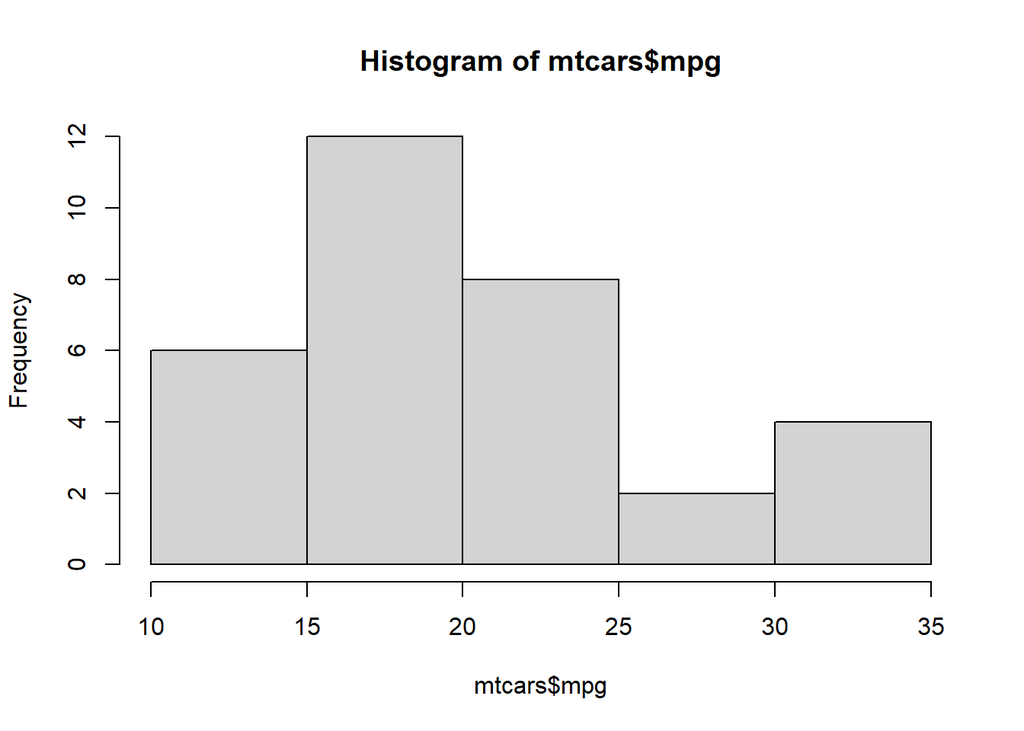

```r
hist(mtcars$mpg) # histogram for all
```

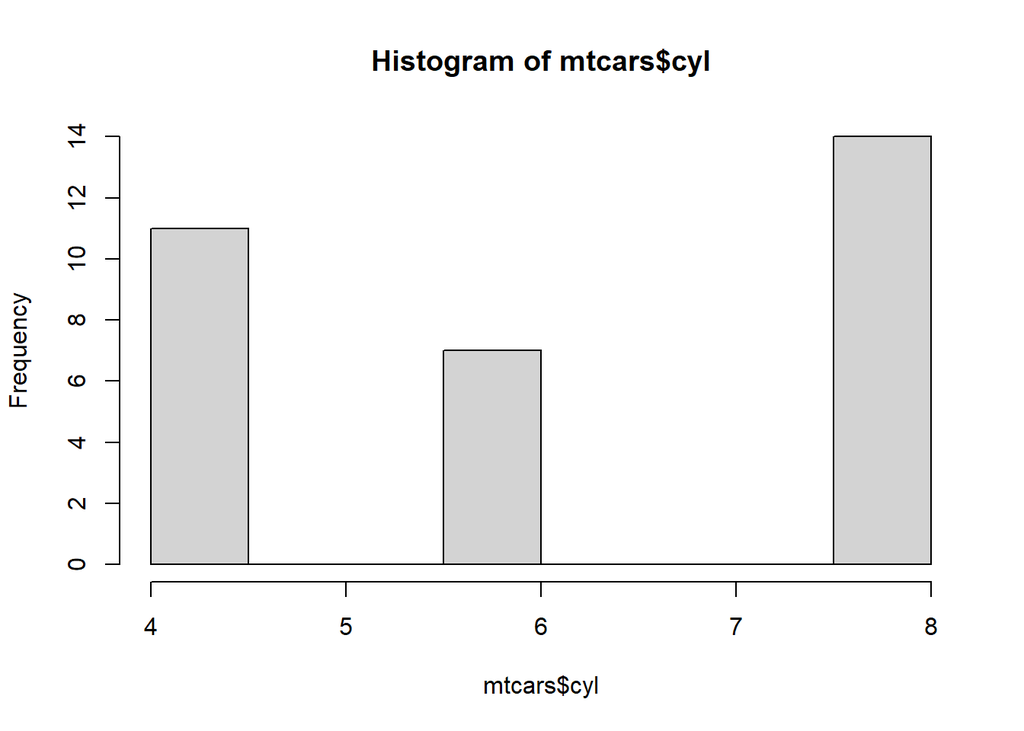

```r
hist(mtcars$cyl)
```

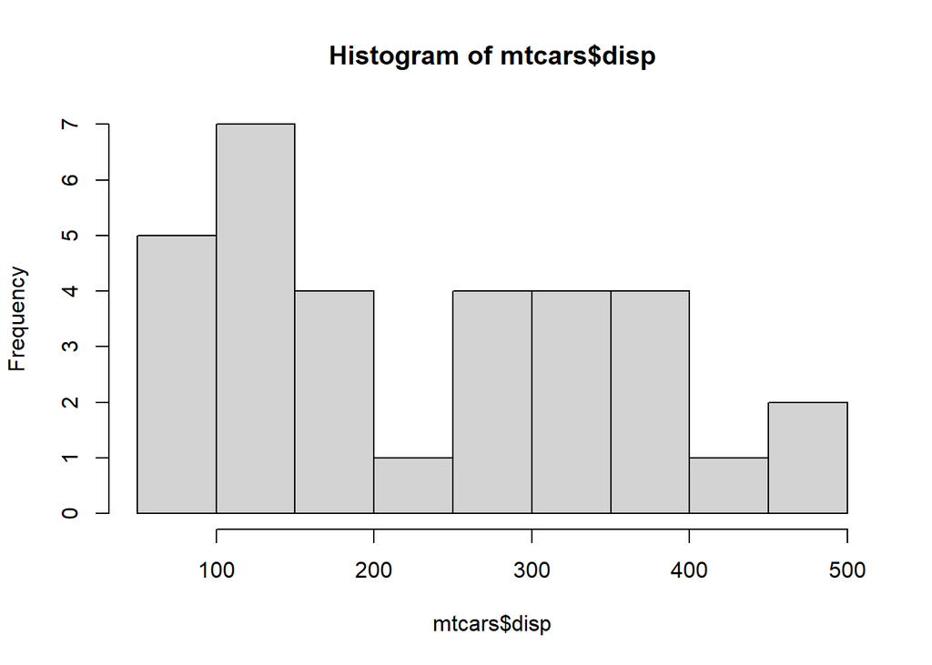

```r
hist(mtcars$disp)
```

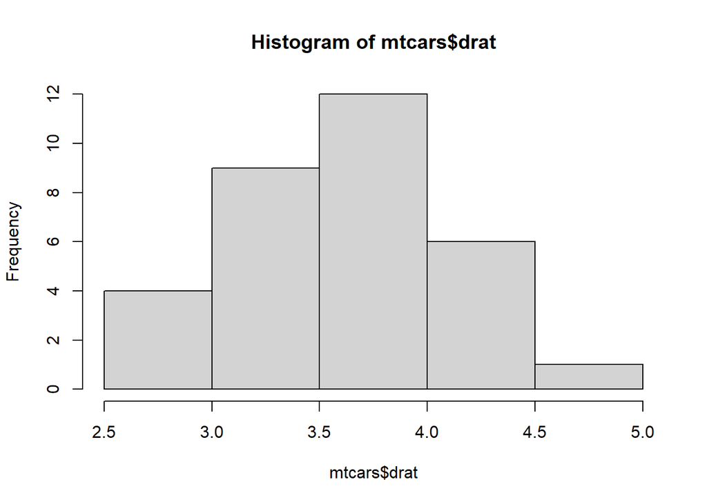

```r
hist(mtcars$drat)
```

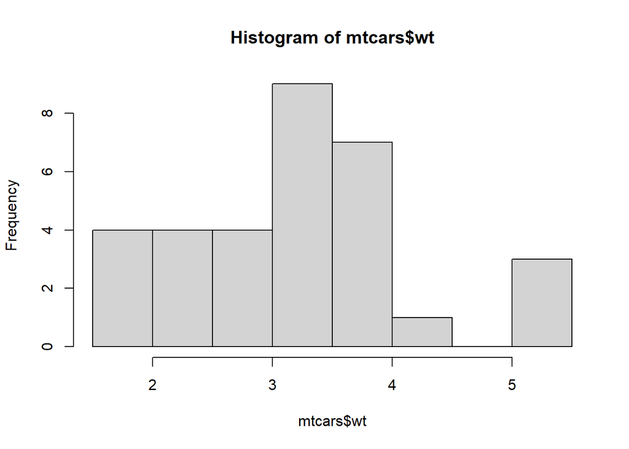

```r
hist(mtcars$wt)
```

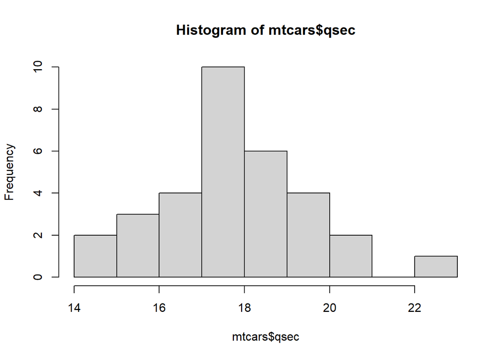

```r
hist(mtcars$qsec)
```

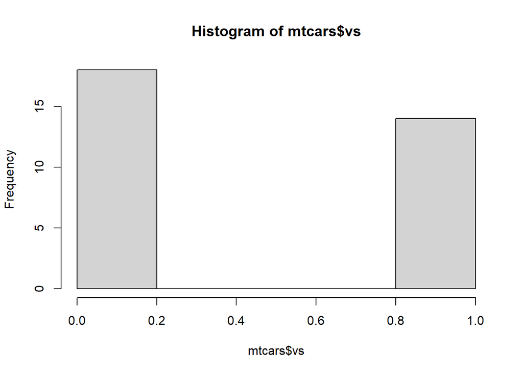

```r
hist(mtcars$vs)
```

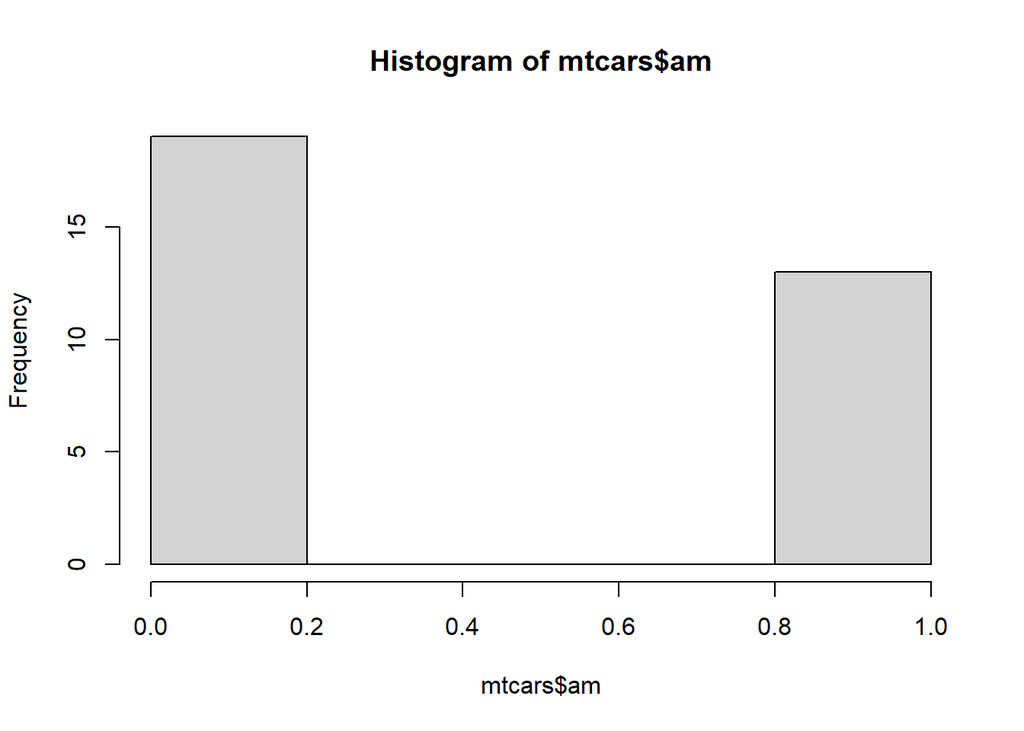

```r
hist(mtcars$am)
```

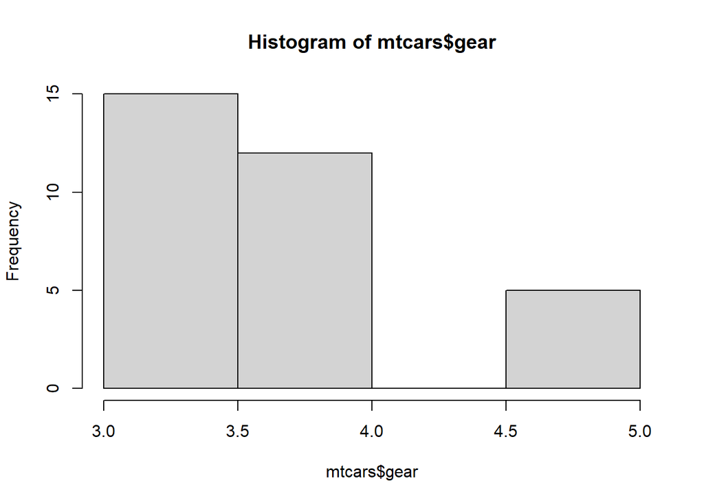

```r
hist(mtcars$gear)
```

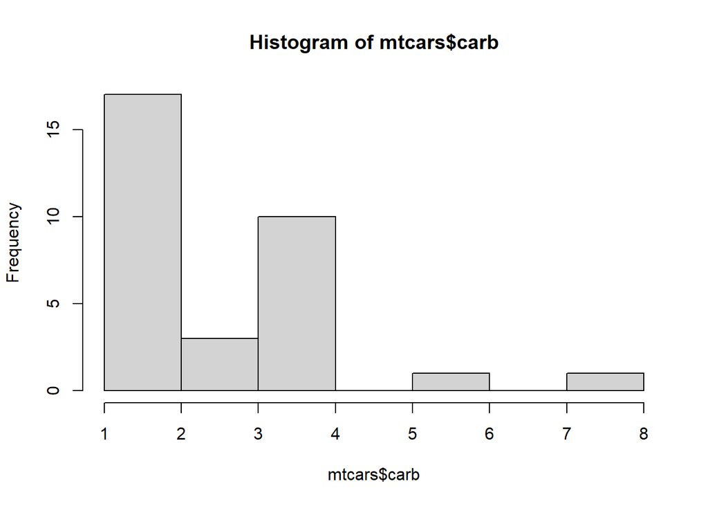

```r
hist(mtcars$carb)
```

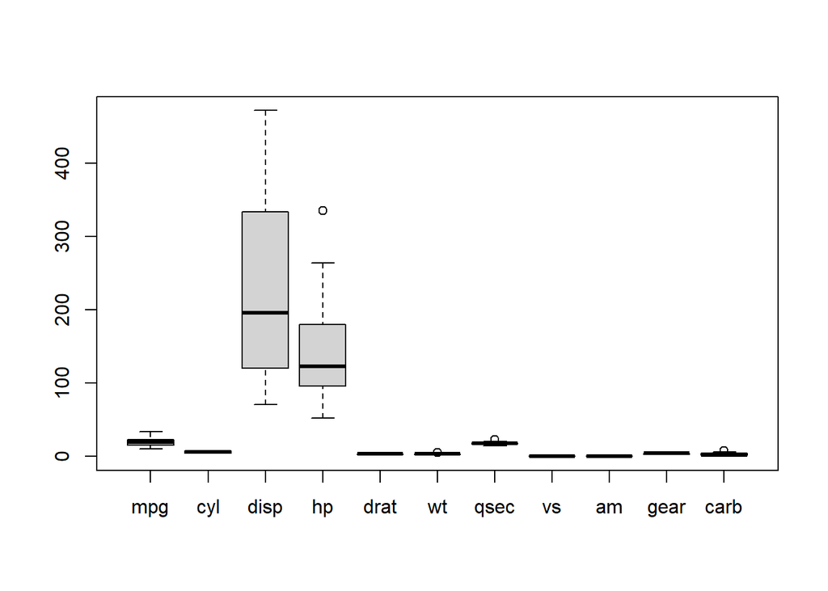

```r
boxplot(mtcars) # do a boxplot
```

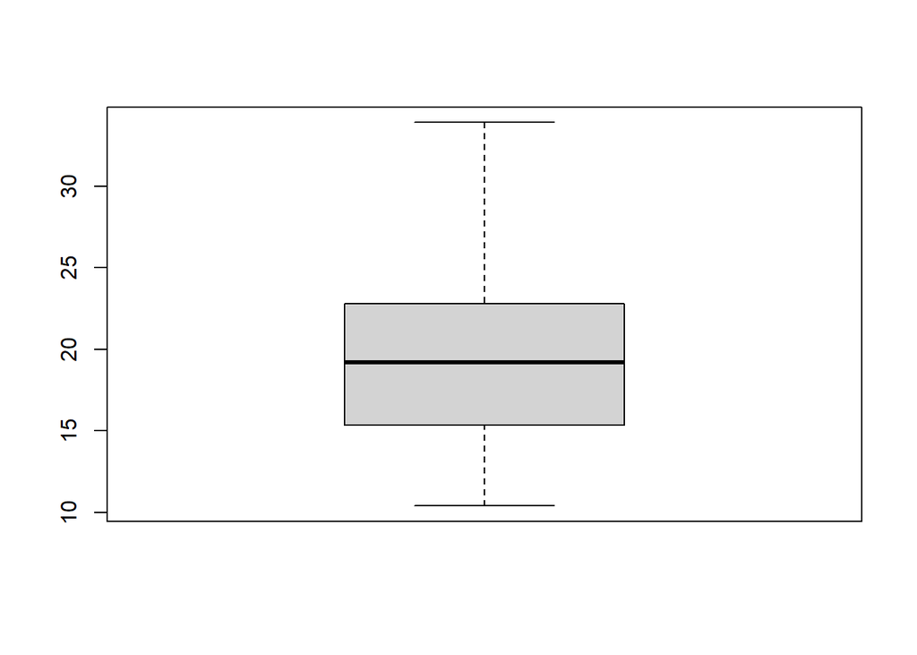

```r
boxplot(mtcars$mpg) # boxplot for all
```

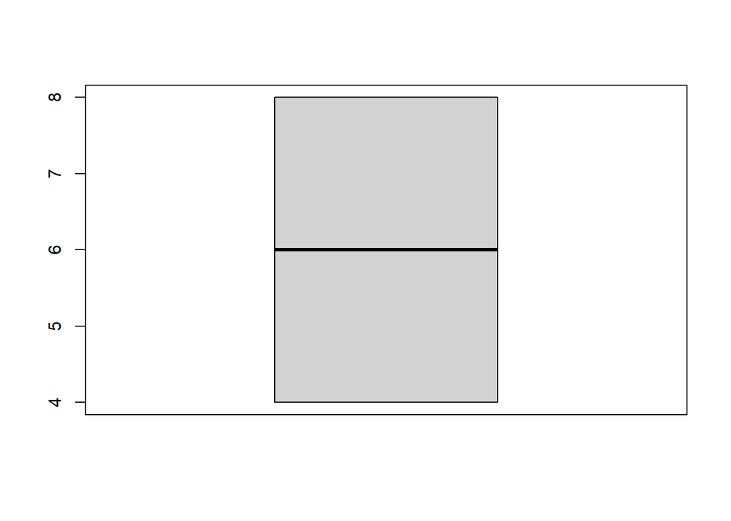

```r
boxplot(mtcars$cyl)
```

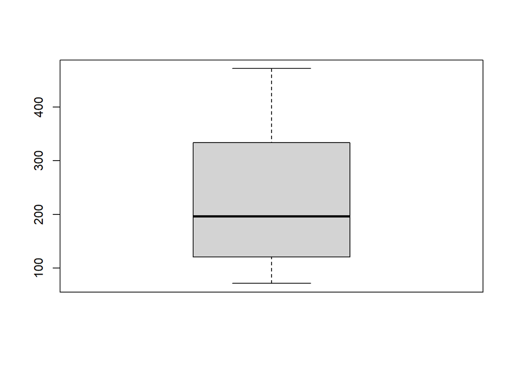

```r
boxplot(mtcars$disp)
```

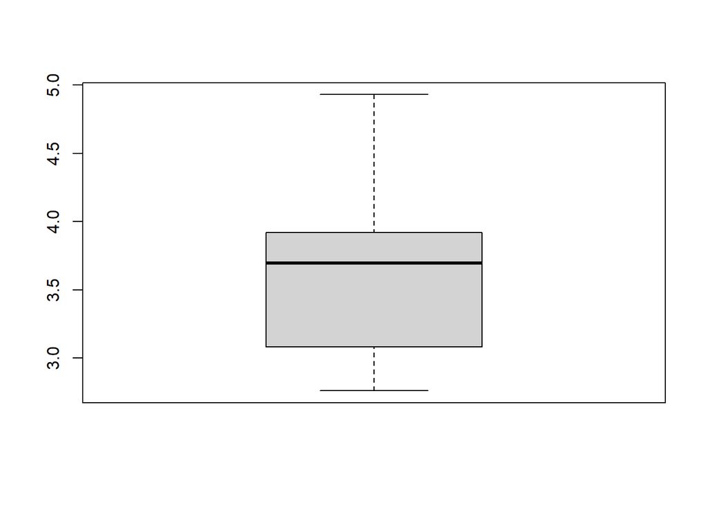

```r
boxplot(mtcars$drat)
```

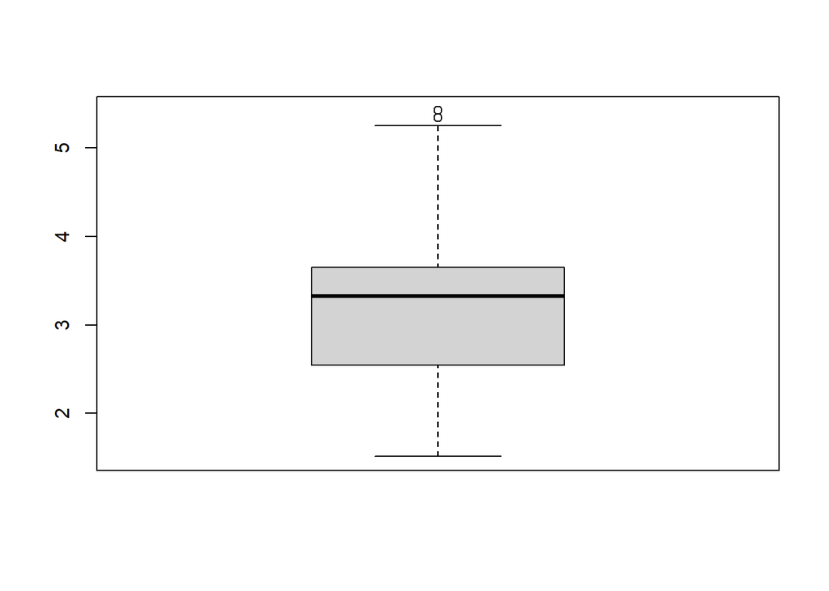

```r
boxplot(mtcars$wt)
```

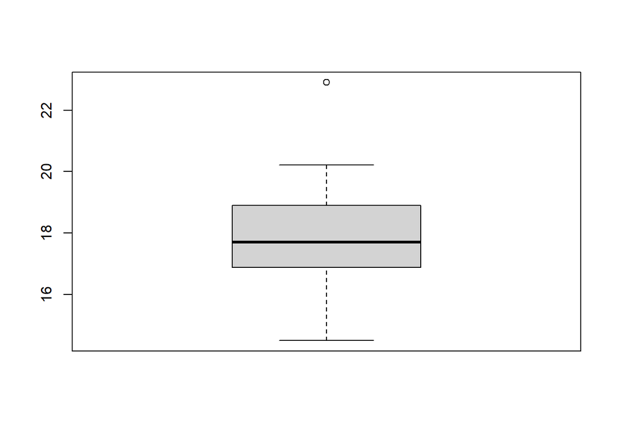

```r
boxplot(mtcars$qsec)
```

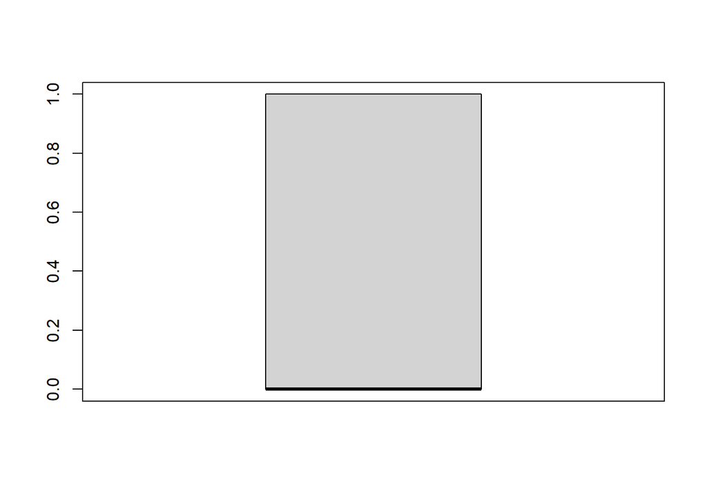

```r
boxplot(mtcars$vs)
boxplot(mtcars$am)
```

[output not shown]

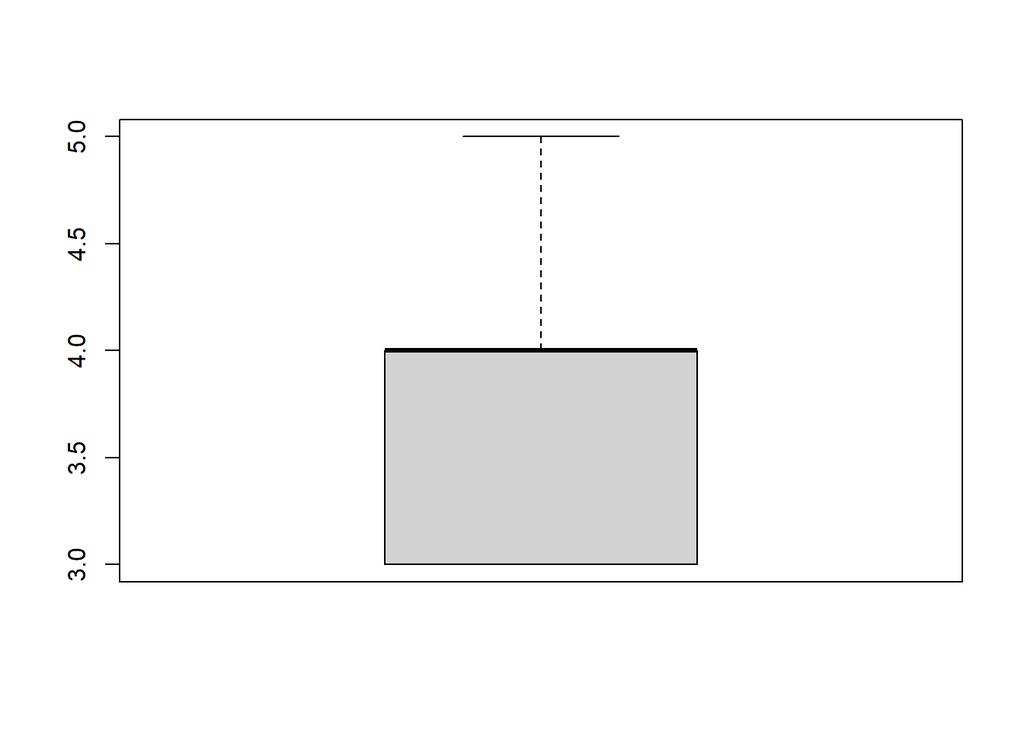

```r
boxplot(mtcars$gear)
```

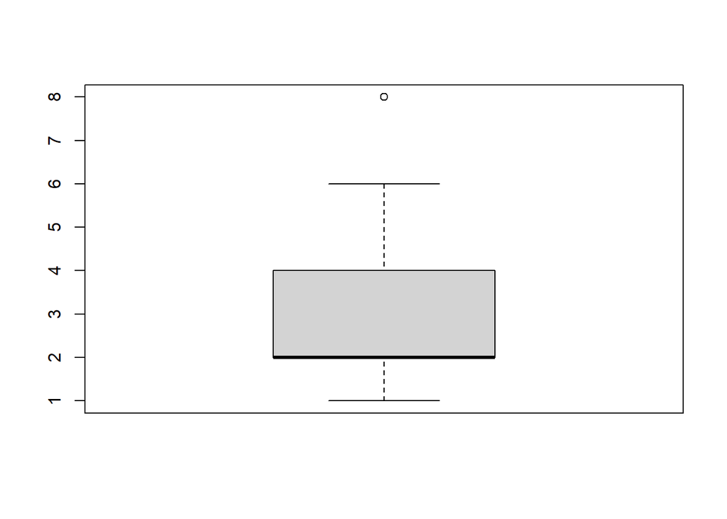

```r
boxplot(mtcars$carb)
```

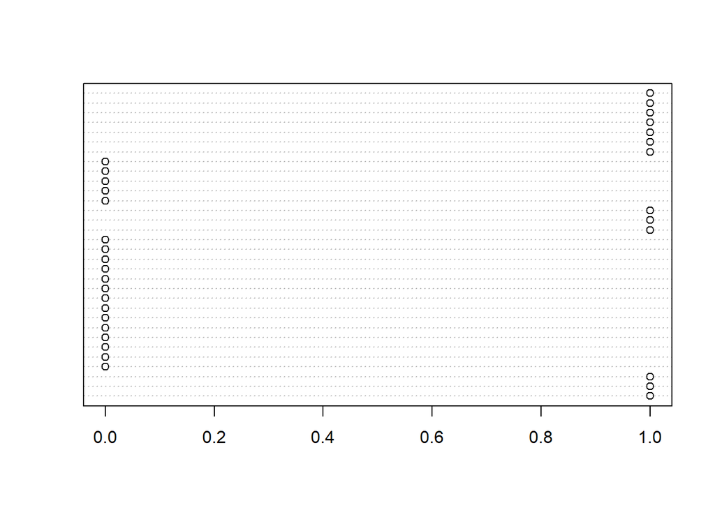

```r
dotchart(mtcars$am) # dot plots for all
```

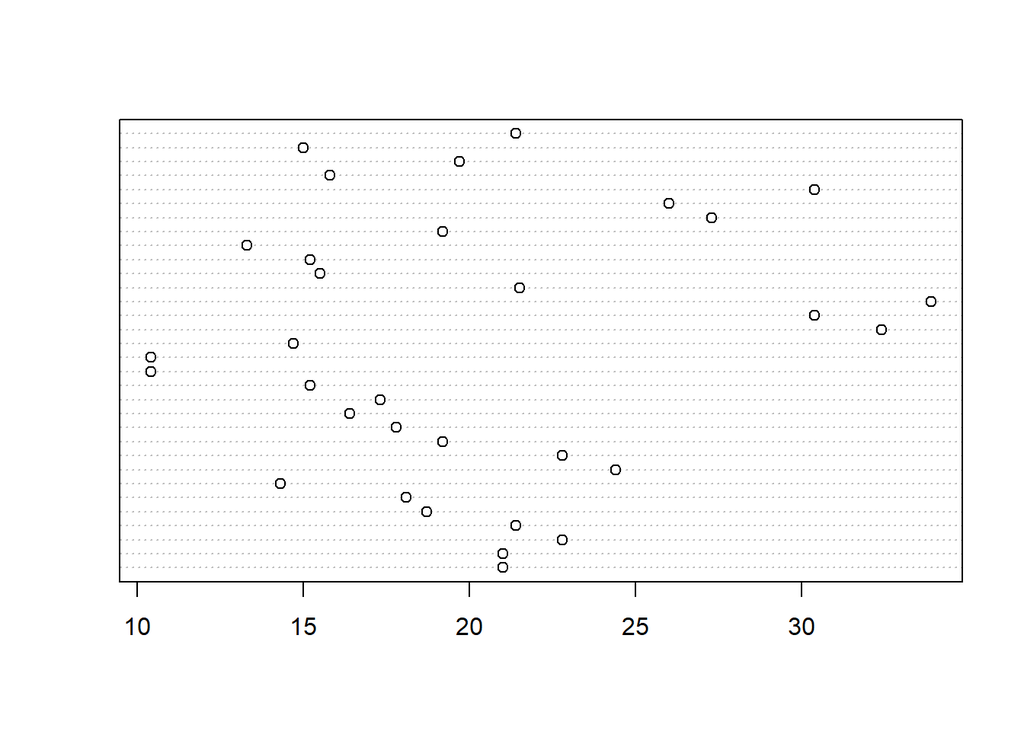

```r
dotchart(mtcars$mpg)
```

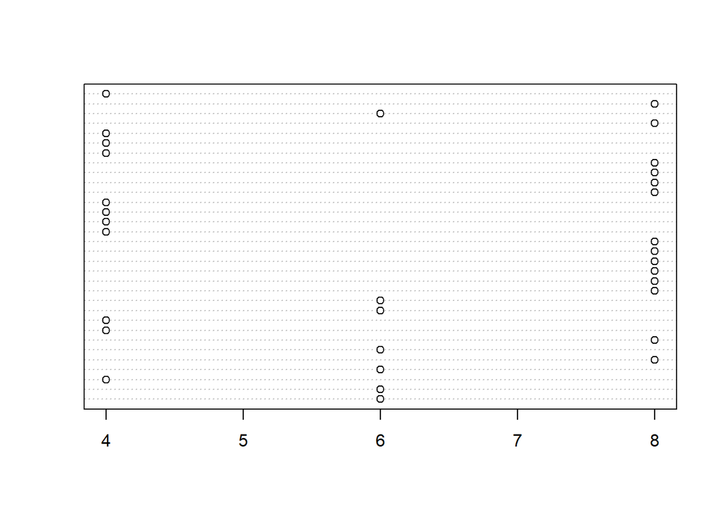

```r
dotchart(mtcars$cyl)
```

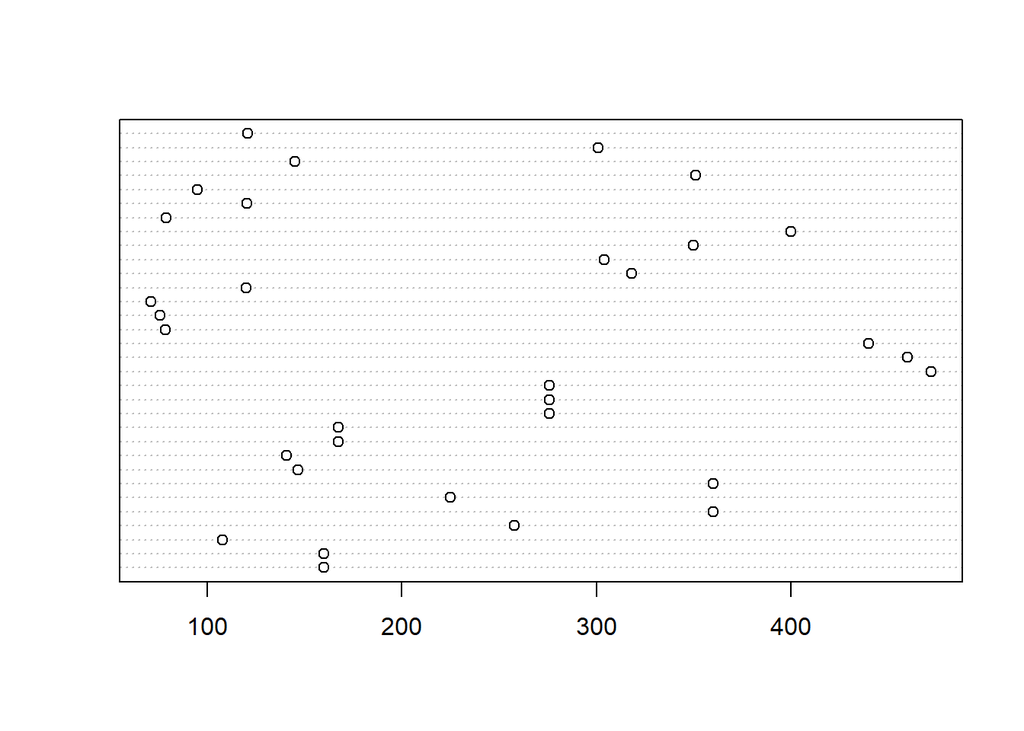

```r
dotchart(mtcars$disp)
```

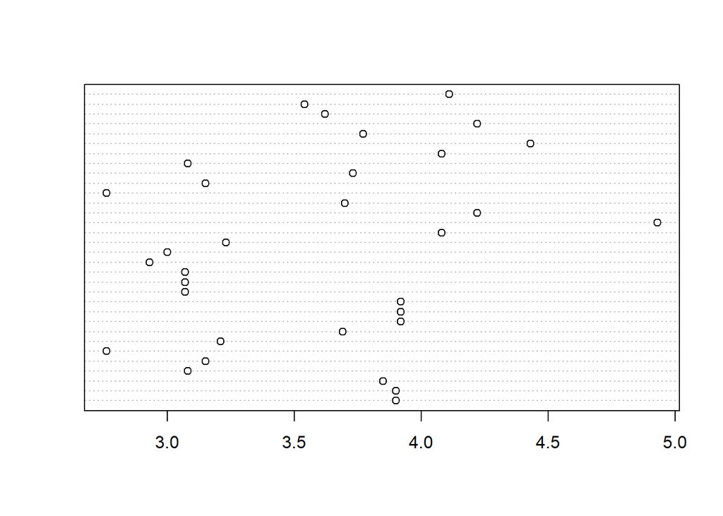

```r
dotchart(mtcars$drat)
```

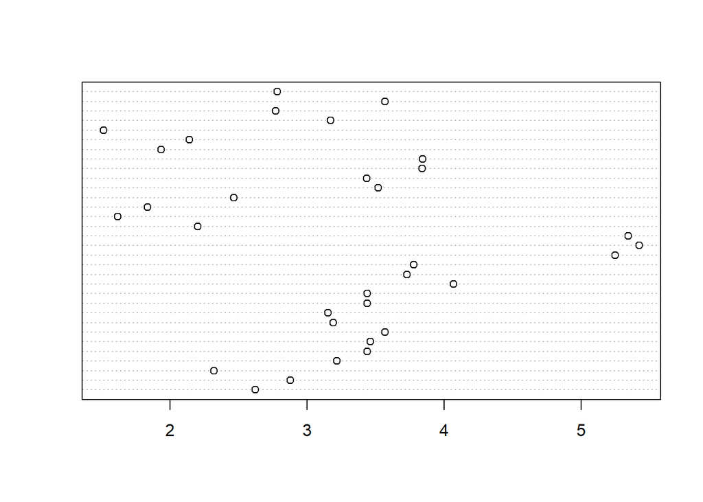

```r
dotchart(mtcars$wt)
```

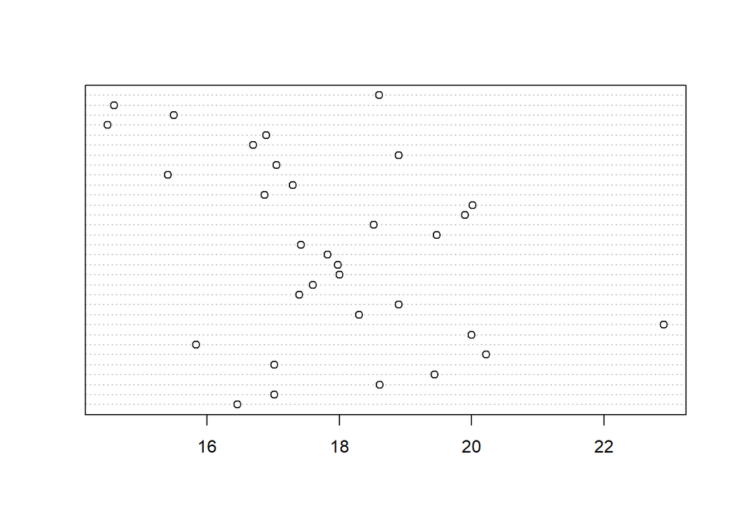

```r
dotchart(mtcars$qsec)
```

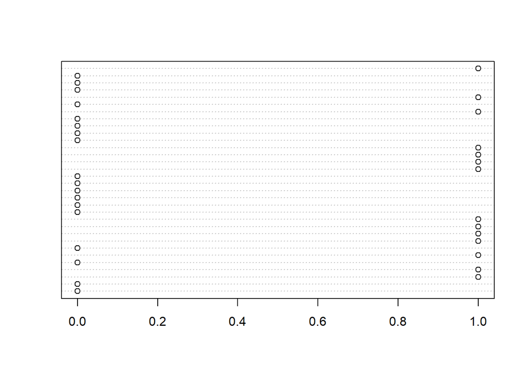

```r
dotchart(mtcars$vs)
```

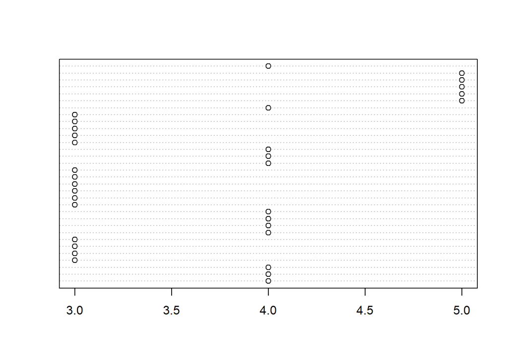

```r
dotchart(mtcars$gear)
```

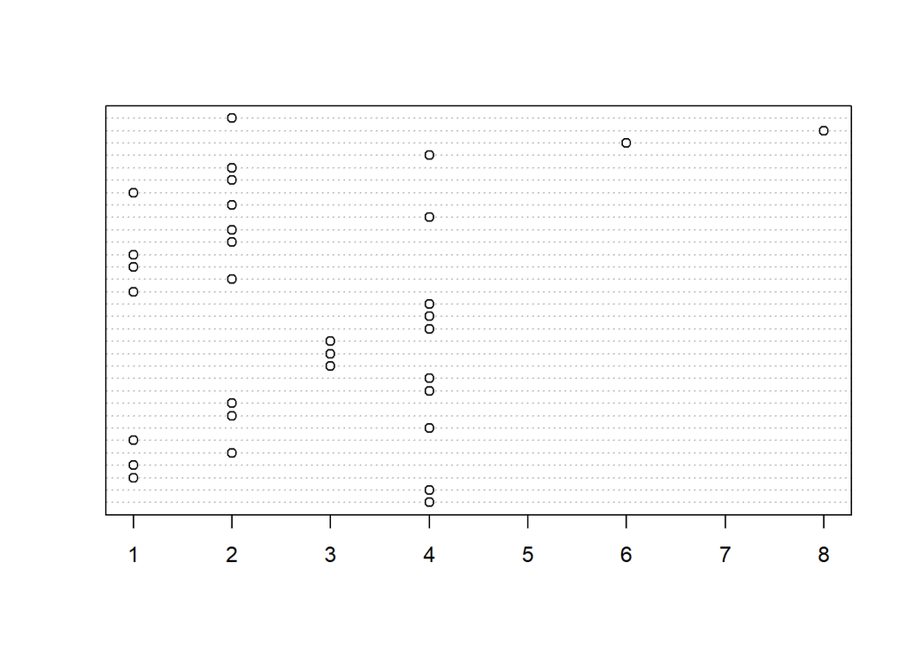

```r
dotchart(mtcars$carb)
```

# 15. Try the command given below: table(mtcars$am)

# What is it doing? Why is this useful for some of the variables in mtcars?

# Use this command to appropriately describe all of the relevant variables in mtcars.

# It counts results and puts them under a column, example 19 0s or 13 1s.

# 19. In our lectures, we mentioned that Boxplots are excellent ways of performing initial observations on the spread of the data. Try the following: boxplot(mtcars)

# Is this particular command useful?

# Yes it is. It makes a box-and-whisker plots of grouped values.

# 20. Make a more useful command and create better box plots for each of the relevant variables in mtcars. Hint: ?boxplots